# Song Lyrics: The Soul of Music

[figure not shown]

Would you rather have music from artists that just make you dance or have music with lyrics that make you think or feel the words? Music is more than something that’s just pleasing to the ears. It has the ability to make you feel, think, and take you on a journey. Music brings us all together, but it’s lyrics that free our souls.

In this project, I apply text mining and natural language processing techniques to get insight into the characteristics of different types of song lyrics. Once I compare the lyrics of songs in distinct music genres, I identify several interesting patterns on their sentiments, topics and content length. Intriguingly, more inspiration is derived by relating the lyrics’ sentiments with the music history.

## I. Sentence Analysis

In order to get some basic patterns and characteristics of different types of song lyrics, I first analyze the content length of songs written in 2016.

### Overview of song length

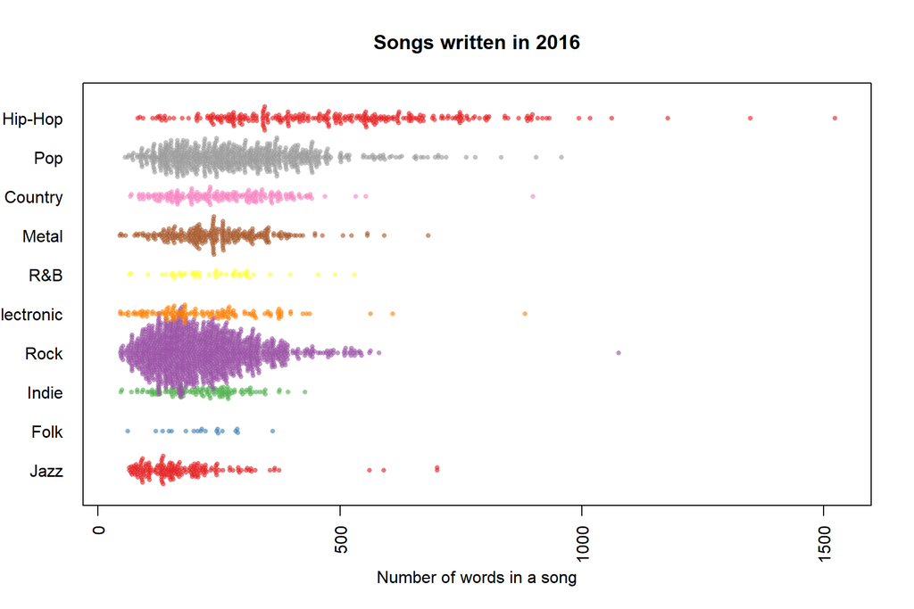

```r
sentence.data <- dt_lyrics %>%
                 filter(genre!='Not Available' & genre!='Other') %>%
                 filter(year==2016)
word.count <- count_words(sentence.data$lyrics)
sentence.data <- cbind(sentence.data, word.count)
sentence.data.beeswarm <- sentence.data %>%
                          select(genre, word.count)
sentence.data.beeswarm$genre <- factor(sentence.data.beeswarm$genre)
sentence.data.beeswarm$order <- reorder(sentence.data.beeswarm$genre,
                                        sentence.data.beeswarm$word.count,
                                        mean,
                                        order=T)
beeswarm(word.count~order,
         data=sentence.data.beeswarm,
         horizontal = TRUE,
         pch=16, col=alpha(brewer.pal(9, "Set1"), 0.6),
         cex=0.6, cex.axis=1, cex.lab=1,
         spacing=5/nlevels(sentence.data.beeswarm$order),
         las=2, xlab="Number of words in a song", ylab="",
         main="Songs written in 2016")
```

We notice that Hip-Hop songs are inarguably longer than other song genres on average and songs from Jazz genre seem to have content that’s shorter in length. This indicates that lyrics is an extremely important part of Hip-Hop songs, which usually consist of a stylized rhythmic music that commonly accompanies rapping. They mainly use lyrics help listeners create a mental image of whatever the song is talking about. On the other hand, since the melody of Jazz music is more colorful, the lyrics of a Jazz song may have to sacrifice a little bit. In fact, some Jazz music subsist just fine without words. It seems that the average song length has sort of stabilized around 250 words for most genres, and rock songs seems to be popular in recent years.

Then, let’s take a look at the songs with the shortest and longest length.

### The shortest song

```r
index <- which.min(sentence.data$word.count)
shortest.data <- sentence.data[index, ]
shortest.sents <- strsplit(shortest.data$lyrics,
                           split='\\n')[[1]] %>%
                  gsub(pattern="^(\\[*[A-Za-z]+\\:*\\])", replacement='') %>%
                  gsub(pattern="^(\\[[A-Za-z]+\\s\\&\\s[A-Za-z]+\\:(\\s\\([A-Za-z]+\\))*\\])", replacement='') %>%
                  gsub(pattern="(\\[[0-9A-Za-z]+\\:*\\])$", replacement='') %>%
                  str_trim()
word.count <- count_words(shortest.sents)
if (any(word.count==0)){
    shortest.sents <- shortest.sents[!(word.count==0)]
    word.count <-word.count[!(word.count==0)]
}
shortest.sents  <- data.frame(shortest.sents)
colnames(shortest.sents) <- toupper(shortest.data$song)
kable(shortest.sents, align = 'c') %>%  kable_styling()
```

| GJ |
| --- |
| wall of death |
| Die! Die! Die! Die! Die! Die! |
| 1step! 2step! |
| Dive! Dive! Dive! Dive! Let’s go! |
| Death! |
| take it easy |
| So so wall of death |
| Burn! Burn! Burn! Burn! Burn! Burn! |
| 4050 |
| Get! Get! Get! Get! Let’s go! |
| 100 Death!! |
| take it easy |

The shortest song is of Metal genre, and it only has 44 words.

### The longest song

```r
index <- which.max(sentence.data$word.count)
longest.data <- sentence.data[index, ]
longest.sents <- strsplit(longest.data$lyrics,
                           split='\\n')[[1]] %>%
                  gsub(pattern="^(\\[*[A-Za-z]+\\:*\\])", replacement='') %>%
                  gsub(pattern="^(\\[[A-Za-z]+\\s\\&\\s[A-Za-z]+\\:(\\s\\([A-Za-z]+\\))*\\])", replacement='') %>%
                  gsub(pattern="(\\[[0-9A-Za-z]+\\:*\\])$", replacement='') %>%
                  str_trim()
word.count <- count_words(longest.sents)
if (any(word.count==0)){
    longest.sents <- longest.sents[!(word.count==0)]
    word.count <-word.count[!(word.count==0)]
}
longest.sents  <- data.frame(longest.sents)
colnames(longest.sents) <- toupper(longest.data$song)
kable(longest.sents, align = 'c') %>%
                  kable_styling()  %>%
                  scroll_box(width = "100%", height = "500px")
```

| CAMPAIGN-SPEECH |
| --- |
| Jumped out of the second floor of a record store |
| With a Treacherous Four cassette and a cassette recorder |
| In Ecuador with Edward Norton |
| Eminem speaks out against Donald Trump on “Campaign Speech” |
| Witness the metamorphosis |
| Of a legend growin’ like an expert swordsman |
| From the Hessian war and |
| Hence the origin of the Headless Horseman |
| Born with the endorphins of a pathetic orphan |
| Endless sores and reservoir |
| Of extension cords in dresser drawers |
| And deadbolts on the bedroom doors |
| And sexual torture kits kept in a separate storage bin |
| Excellent boyfriend |
| Use intercourse to settle scores |
| With women who have been vendettas towards men |
| Dickhead is forced in and the shredded foreskin |
| Red is torn and they’re only bein’ fed a portion |
| Bed sores in sore shins |
| Pregnant whores can get abortions |
| Fetish for stickin’ metal forks in, self-absorption |
| Skeletor, I went to Hell and fell a floor |
| A predator, I’m headed for competitors |
| Better warn ’em, what I lack in tact and a set of morals |
| I make up for in metaphors like a cosmetic store |
| Stegosaurus, Chuck Norris with a thesaurus |
| Yes, of course, I mess up once |
| You want some? Come and get some, boys! |
| I’m givin’ Daniel Pantaleo a refresher course |
| On excessive force and pressure points |

[output cut: 156 more lines]

The longest one is a Hip-Hop song with no doubt and there are 1523 words in its lyrics.

## II. Sentiment Analysis

In the second part, I analyze the sentiments expressed by different kinds of music. Using sentiment analysis, we can get to know how the artists convey their thoughts and emotions through lyrics to their listeners. I analyze each song based on the eight basic emotions and two sentiments, namely anger, fear, anticipation, trust, surprise, sadness, joy, disgust, negative and positive.

```r
# sentiment analysis
tokenized <- dt_lyrics %>%
             select(genre, stemmedwords) %>%
             unnest_tokens(word, stemmedwords)
# the nrc dictionary
nrc <- get_sentiments("nrc")
sentiment.count <- tokenized %>%
                   group_by(genre) %>%
                   inner_join(nrc) %>%
                   count(sentiment) %>%
                   spread(sentiment, n, fill=0) %>%
                   filter(genre!='Not Available' & genre!='Other') %>%
                   ungroup()
sentiment.level <- sentiment.count$genre
matrix <- as.matrix(sentiment.count %>% select(-genre))
sentiment.score <- diag(1/(apply(matrix,1,sum))) %*% matrix
rownames(sentiment.score) <- sentiment.level
d3heatmap(sentiment.score, colors='Reds', scale='none', Rowv=T, Colv=F,
          xaxis_font_size="15px")
```

[interactive chart not shown]

According to this heatmap, we know that most of the genres are trying to show positivity, which is clearly indicated by music like Jazz, Pop, Electronic and Folk. Metal and Hip-Pop songs tend to convey negative emotions while music genres such as Indie and Rock express neutral sentiments in genral. Basically, none of these genres talk much about surprise and disgust. What’s more, the reason why Metal music is so negative is that it uses more words with anger, fear and sadness. On the other hand, joy plays an important role in Jazz songs.

### Wordclouds

Since the emotions conveyed by Jazz and Metal songs seem to differ a lot, I count the frequency of words in them, and use wordclouds to find the most frequently used words in their lyrics.

```r
# wordcloud for jazz
cloud.jazz <- dt_lyrics %>%
              filter(genre=="Jazz") %>%
              select(stemmedwords)
corpus.jazz <- VCorpus(VectorSource(cloud.jazz))
dtm.jazz <- DocumentTermMatrix(corpus.jazz)
word.jazz <- colnames(as.matrix(dtm.jazz))
cloud.jazz <- data.frame(word=word.jazz,
                         freq=apply(as.matrix(dtm.jazz), 2, sum))
cloud.jazz <- cloud.jazz[order(cloud.jazz$freq, decreasing=T), ]
wordcloud2(data=cloud.jazz[1:200,], size=1.2)
```

[interactive chart not shown]

In Jazz music, the word “love” holds a dominant position among all the words. Other words like “baby”, “night”, “heart” and “dream” also appear frequently.

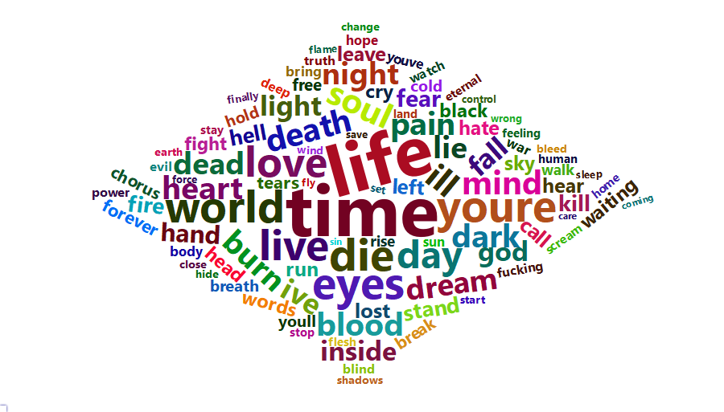

```r
# wordcloud for metal
cloud.metal <- dt_lyrics %>%
              filter(genre=="Metal") %>%
              select(stemmedwords)
corpus.metal <- VCorpus(VectorSource(cloud.metal))
dtm.metal <- DocumentTermMatrix(corpus.metal)
word.metal <- colnames(as.matrix(dtm.metal))
cloud.metal <- data.frame(word=word.metal,
                          freq=apply(as.matrix(dtm.metal), 2, sum))
cloud.metal <- cloud.metal[order(cloud.metal$freq, decreasing=T), ]
picture.metal <- wordcloud2(data=cloud.metal[1:100,], size=0.5, shape="diamond")
saveWidget(picture.metal,"metal.html",selfcontained = F)
file <- webshot::webshot("metal.html","metal.png",vwidth = 900, vheight = 500, delay =10)
```

From the wordcloud of Metal music, we can see that, compared with Jazz music, many depressing words such as “dark”, “blood”, “die”, “pain” and “lie” are mentioned very often by Metal music artists. We can also conclude that Metal songs seem to consist of a mixture of emotions.

### The music history

Next, I relate the lyrics’ sentiments with the music history to see if I can get more inspiration. Using stack plot, I visualize the songs’ emotion flow as time goes on. Jazz, Pop, Electronic and Metal musics are selected here to explore the patterns behind music history.

```r
# sentiment analysis
# summary the emotions in another way
# emotions <- get_nrc_sentiment(dt_lyrics$stemmedwords)
# weights <- 1/count_words(dt_lyrics$stemmedwords)
# sentiments <- NULL
# for (i in 1:nrow(emotions)){
#   sentiments <- rbind(sentiments,
#                       emotions[i,]*weights[i])
# }

load("../output/sentiments.RData")
senti.df <- cbind(dt_lyrics %>% select(year, genre, id, stemmedwords),
                  sentiments)
```

```r
stackplot <- function(genrename){
  senti <- senti.df %>%
           filter(genre==genrename)
  senti.stack <-  senti %>%
                  group_by(year) %>%
                  summarise(
                       anger=mean(anger),
                       anticipation=mean(anticipation),
                       disgust= mean(disgust),
                       fear=mean(fear),
                       joy=mean(joy),
                       sadness=mean(sadness),
                       surprise=mean(surprise),
                       trust=mean(trust)
                      ) %>%
                  gather(key="sentiment", value="score", -year)
  # percentage <- function(scores){
  #   return(scores/sum(scores))
  # }
  # senti.metal.stack <- cbind(senti.metal.stack %>% select(year),
  #                            t(apply(senti.metal.stack %>% select(-year),
  #                                  1, percentage))
  #                            ) %>%
  #                            gather(key="sentiment", value="score", -year)

  p <- ggplot(data=senti.stack, aes(x=year, y=score, fill=sentiment)) +
              geom_area(colour="black") +
              scale_fill_manual(values=rainbow(8)) +
              ylab("")+
              ggtitle(genrename) +
              theme_bw()+
              theme(plot.title = element_text(hjust = 0.5, face = "bold", size=15),
                    panel.grid=element_blank(),
                    axis.text.y=element_blank(),
                    axis.ticks.y=element_blank()
                    )

  return(p)
}
```

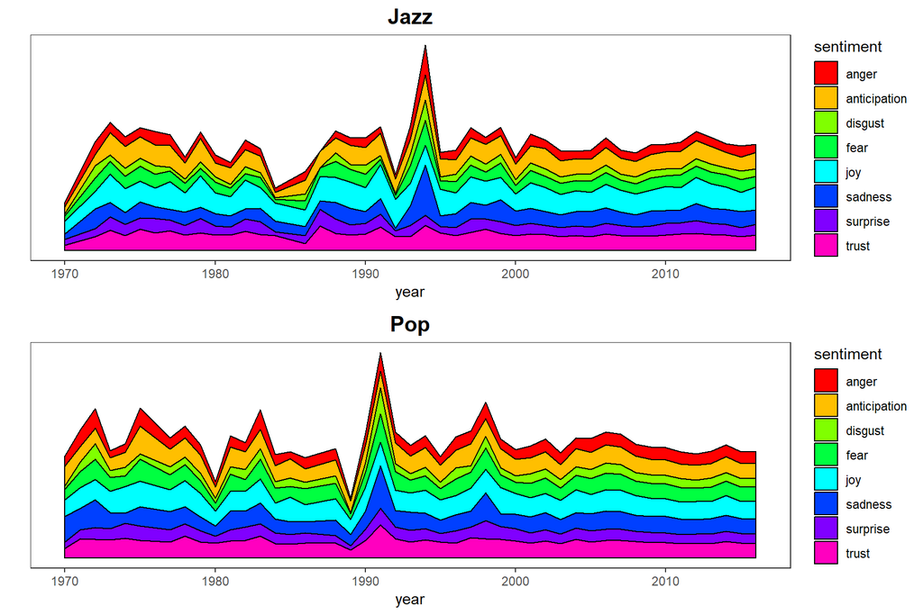

```r
p1 <- stackplot("Jazz")
p2 <- stackplot("Pop")
p3 <- stackplot("Electronic")
p4 <- stackplot("Metal")
grid.arrange(p1,p2)
```

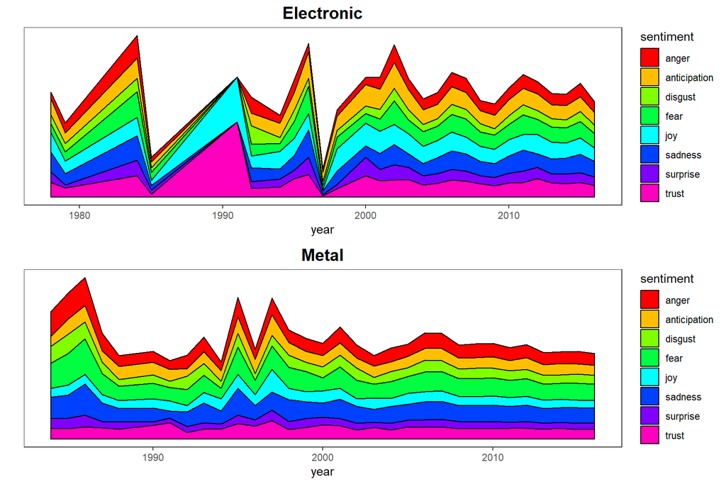

```r
grid.arrange(p3,p4)
```

Electronic music has gone through a series of cycles over the decades as its sentiments flow fluctuates a lot during the music history.

Although Metal music delivers more negative words in fear, sadness and anger, it develops with a relatively flat and smooth emotion flow.

## III. Topic Modeling

Lastly, I utilize LDA model, a method for unsupervised classification of documents, to discover more difference between different musical genres. I manually set the topic number to be 10.

```r
# the most likely topics for each document
lda.topics <- as.matrix(topics(lda.out))
# matrix containing the most likely terms for each topic
lda.terms <- as.matrix(terms(lda.out, 30))
topic.prob <- as.data.frame(lda.out@gamma)
topic.beta <- scale(lda.out@beta)
top.terms <- NULL
for (i in 1:k){
  order <- order(topic.beta[i,], decreasing=T)[1:20]
  top.terms <- rbind(top.terms, lda.out@terms[order])
}
#top.terms
kable(lda.terms, align = 'c') %>%
                  kable_styling()  %>%
                  scroll_box(width = "100%", height = "500px")
```

| Topic 1 | Topic 2 | Topic 3 | Topic 4 | Topic 5 | Topic 6 | Topic 7 | Topic 8 | Topic 9 | Topic 10 |
| --- | --- | --- | --- | --- | --- | --- | --- | --- | --- |
| dance | bitch | night | youre | run | time | love | eyes | god | hand |
| people | shit | light | baby | mind | life | ill | world | soul | head |
| rock | money | home | girl | feeling | ive | heart | fall | lord | fire |
| play | niggas | sing | call | break | day | youll | dream | heaven | stand |
| roll | hit | song | boy | tonight | live | walk | lie | save | burn |
| hes | gon | sky | shes | stop | hold | cry | words | blood | watch |
| town | smoke | sun | bad | start | waiting | care | left | dead | round |
| ready | fucking | coming | talk | move | stay | forever | lost | carry | set |
| street | ass | bring | miss | wrong | change | true | leave | kill | beat |
| drink | verse | stars | night | chorus | gotta | kiss | inside | die | hell |
| city | told | blue | alright | lose | youve | hurt | hear | war | cold |
| friend | jump | day | crazy | hard | hope | mine | free | angel | black |
| kids | imma | rain | friend | line | die | sweet | breath | dark | ground |
| ride | real | shine | babe | whats | till | arms | sleep | born | air |
| woman | dope | fly | thinking | real | forget | lonely | tears | death | pull |
| music | goin | morning | bout | didnt | matter | happy | close | king | sound |
| party | damn | road | whos | takes | fight | fool | pain | follow | late |
| house | hook | wind | worth | body | reason | smile | truth | ghost | feet |
| theyre | tryna | water | mama | chance | weve | lover | wake | earth | fill |
| sit | ima | grow | hate | shake | learn | dear | alive | lead | stone |
| ring | gotta | dark | honey | slow | remember | touch | broken | peace | scream |
| hear | bout | moon | drive | step | understand | darling | hide | rise | bone |
| trouble | pop | lay | youve | control | waste | lips | easy | power | wave |
| wild | key | low | phone | game | tomorrow | magic | beautiful | faith | raise |
| cool | check | sea | pretty | happen | strong | meant | goodbye | fight | skin |
| daddy | yall | remember | worry | bit | anymore | found | memories | devil | flame |
| bang | ride | river | told | play | doesnt | belong | couldnt | cross | blow |
| hair | club | summer | perfect | touch | answer | sad | deep | world | throw |
| fun | talk | whoa | minute | sign | moment | guess | promise | fear | shame |
| red | motherfucker | meet | mine | win | pass | someday | voice | father | kick |

The table shows the most popular terms in each topic. For example, Topic 1 contains words:“Friend”,“Party” and “Play”; Topic 3 contains words:“Sky”,“Sea” and “Wind”. Based on the most prominent terms in each topic, I tag them as **Friend, Dirty Word, Nature, Family, Game, Life, Love, Dream, Belief and Body**.

```r
topictag <- c("Friend", "Dirty Word", "Nature", "Family","Game",
              "Life", "Love", "Dream", "Belief", "Body" )
colnames(topic.prob) <- topictag
topic.df <- cbind(topic.data %>% select(genre),
                  topic.prob)
topic.summary <- tbl_df(topic.df) %>%
                 group_by(genre) %>%
                 summarise_each(funs(mean))
rownames(topic.summary) <- topic.summary$genre
topic.heatmap <- topic.summary %>% select(-genre)
d3heatmap(topic.heatmap, colors='Reds', scale='none', Rowv=T, Colv=F,
          xaxis_font_size="15px")
```

[interactive chart not shown]

We could see that the Dirty Word cell of Hip-Hop has the darkest color in the heatmap. That is to say, obscene and vulgar language is widely used by Hip-Hop music artists, and their topics are unfortunately linked to violence, sexuality, or drug use. Metal music pays much attention to topic related to Belief, which means it may contain significant religious components and messages. Actually, a big branch of Metal music is called Christian metal. What’s more, Rock and Indie tends to have similar weight allocation among these topics.

## IV. Conclusions

- In general, Hip-Hop music tend to use more words in their lyrics to express their emotions and impress the listerners, while the lyrics of a Jazz song may have to sacrifice for its colorful melody. For other musical genres, the average song length has sort of stabilized around 250 words.
- Basically, the majority of the genres tend to show positivity. Metal and Hip-Pop songs tend to convey negative emotions, but none of these songs talk much about surprise and disgust. Their emotion flows also behave differently during the music history. Music such as Electronic goes through a series of cycles while Metal music seems to evolve smoothly. In fact, each genre has its unique music history.
- The topics of Hip-Hop songs are unfortunately related to violence, sexuality, or drug use. Metal music surprisingly contains significant religious components. Some of the music genres do not show much difference on their topics.